# Telco Customer Churn — Predicting Churn and Monthly Charges

End-to-end ML analysis: EDA, feature engineering, model ladder, and honest evaluation

Author

Matej

Published

July 2, 2026

## 1. Introduction

This report works through a full, leakage-safe machine learning pipeline on the [Telco Customer Churn](https://www.kaggle.com/datasets/blastchar/telco-customer-churn) dataset (7,043 customers, 21 columns from a US telecom provider), answering two real-world questions:

- **Classification** — will a given customer **churn** (cancel their service)? Target: `Churn`.
- **Regression** — how much is a customer likely to be billed per month, i.e. what is their **`MonthlyCharges`**? Framed as: given a customer’s plan and service mix, what monthly charge would we expect — useful for pricing sanity checks and flagging accounts that are billed unusually high or low for their service mix.

A single fixed random seed is used throughout for reproducibility.

```python
import numpy as np
import pandas as pd
import matplotlib.pyplot as plt
import seaborn as sns

RANDOM_STATE = 42
np.random.seed(RANDOM_STATE)

sns.set_theme(style="whitegrid")
pd.set_option("display.max_columns", 50)
```

## 2. Load & inspect the data

```python
df_raw = pd.read_csv("../data/WA_Fn-UseC_-Telco-Customer-Churn.csv")
print(df_raw.shape)
df_raw.head(3)
```

```
(7043, 21)
```

|  | customerID | gender | SeniorCitizen | Partner | Dependents | tenure | PhoneService | MultipleLines | InternetService | OnlineSecurity | OnlineBackup | DeviceProtection | TechSupport | StreamingTV | StreamingMovies | Contract | PaperlessBilling | PaymentMethod | MonthlyCharges | TotalCharges | Churn |
| --- | --- | --- | --- | --- | --- | --- | --- | --- | --- | --- | --- | --- | --- | --- | --- | --- | --- | --- | --- | --- | --- |
| 0 | 7590-VHVEG | Female | 0 | Yes | No | 1 | No | No phone service | DSL | No | Yes | No | No | No | No | Month-to-month | Yes | Electronic check | 29.85 | 29.85 | No |
| 1 | 5575-GNVDE | Male | 0 | No | No | 34 | Yes | No | DSL | Yes | No | Yes | No | No | No | One year | No | Mailed check | 56.95 | 1889.5 | No |
| 2 | 3668-QPYBK | Male | 0 | No | No | 2 | Yes | No | DSL | Yes | Yes | No | No | No | No | Month-to-month | Yes | Mailed check | 53.85 | 108.15 | Yes |

```python
df_raw.dtypes
```

```
customerID           object
gender               object
SeniorCitizen         int64
Partner              object
Dependents           object
tenure                int64
PhoneService         object
MultipleLines        object
InternetService      object
OnlineSecurity       object
OnlineBackup         object
DeviceProtection     object
TechSupport          object
StreamingTV          object
StreamingMovies      object
Contract             object
PaperlessBilling     object
PaymentMethod        object
MonthlyCharges      float64
TotalCharges         object
Churn                object
dtype: object
```

**Quirks found on inspection:**

- `customerID` is a unique identifier with no predictive value — dropped before modeling.
- `TotalCharges` is loaded as `object` (string), not numeric. This is because 11 customers with `tenure == 0` (brand-new customers) have a blank string `" "` instead of a number — pandas falls back to object dtype for the whole column.
- `SeniorCitizen` is encoded as `0`/`1` (already numeric) while most other binary features (`Partner`, `Dependents`, `PhoneService`, …) are encoded as `"Yes"`/`"No"` strings.
- Several categorical columns use a 3-way encoding (e.g. `"No"`, `"Yes"`, `"No internet service"`) which is really “No” in disguise for customers without internet service at all.

```python
df_raw["TotalCharges"] = pd.to_numeric(df_raw["TotalCharges"], errors="coerce")
print(f"Rows with missing TotalCharges: {df_raw['TotalCharges'].isna().sum()}")
df_raw.loc[df_raw["TotalCharges"].isna(), ["tenure", "MonthlyCharges", "TotalCharges"]]
```

```
Rows with missing TotalCharges: 11
```

|  | tenure | MonthlyCharges | TotalCharges |
| --- | --- | --- | --- |
| 488 | 0 | 52.55 | NaN |
| 753 | 0 | 20.25 | NaN |
| 936 | 0 | 80.85 | NaN |
| 1082 | 0 | 25.75 | NaN |
| 1340 | 0 | 56.05 | NaN |
| 3331 | 0 | 19.85 | NaN |
| 3826 | 0 | 25.35 | NaN |
| 4380 | 0 | 20.00 | NaN |
| 5218 | 0 | 19.70 | NaN |
| 6670 | 0 | 73.35 | NaN |
| 6754 | 0 | 61.90 | NaN |

As suspected, every missing `TotalCharges` value belongs to a customer with `tenure == 0` — they haven’t been billed yet, so there is nothing to fill in from a “true” value. We treat this as **missing-not-at-random but explainable**: it isn’t noise, it’s structural (new customer).

```python
df_raw.isna().sum().loc[lambda s: s > 0]
```

```
TotalCharges    11
dtype: int64
```

## 3. Cleaning

**Strategy for the 11 missing `TotalCharges` rows:** since `TotalCharges ≈ tenure × MonthlyCharges` for this dataset, and `tenure == 0` for all of them, the mathematically consistent value is `0`. We impute with `0` rather than a mean/median, because the mean would fabricate spending that never happened for a customer who just signed up.

```python
df = df_raw.copy()
df["TotalCharges"] = df["TotalCharges"].fillna(0.0)
assert df["TotalCharges"].isna().sum() == 0
```

**Duplicate check:**

```python
print(f"Duplicate customerID rows: {df['customerID'].duplicated().sum()}")
```

```
Duplicate customerID rows: 0
```

**Target encoding.** `Churn` (`Yes`/`No`) is mapped to `1`/`0` for the classification task. `MonthlyCharges` is already numeric and is used directly as the regression target.

```python
df["Churn"] = df["Churn"].map({"Yes": 1, "No": 0})
df["Churn"].value_counts(normalize=True)
```

```
Churn
0    0.73463
1    0.26537
Name: proportion, dtype: float64
```

**Outlier check on numeric columns.** `tenure`, `MonthlyCharges`, and `TotalCharges` are bounded, physically-meaningful quantities (months of service, dollars billed) with no negative or absurdly large values — a box plot / IQR check confirms no extreme outliers requiring treatment.

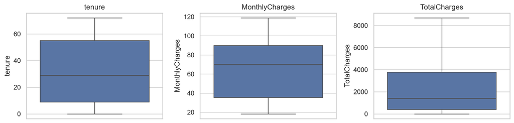

```python
numeric_cols = ["tenure", "MonthlyCharges", "TotalCharges"]
fig, axes = plt.subplots(1, 3, figsize=(12, 3))
for ax, col in zip(axes, numeric_cols):
    sns.boxplot(y=df[col], ax=ax)
    ax.set_title(col)
plt.tight_layout()
plt.show()
```

## 4. Exploratory data analysis

### 4.1 Target balance (classification)

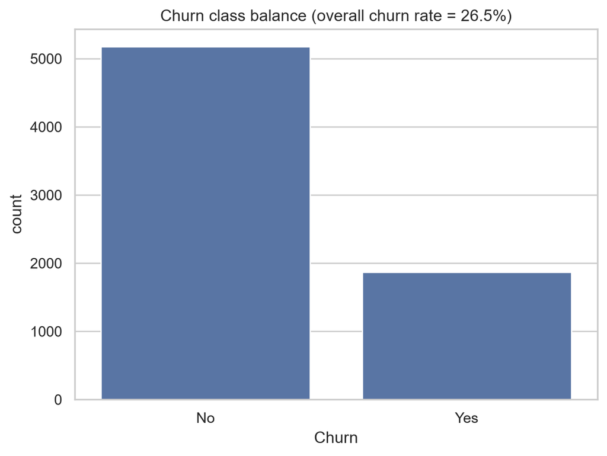

```python
churn_rate = df["Churn"].mean()
ax = sns.countplot(x=df["Churn"].map({0: "No", 1: "Yes"}))
ax.set_title(f"Churn class balance (overall churn rate = {churn_rate:.1%})")
ax.set_xlabel("Churn")
plt.show()
```

The classes are imbalanced (~26.5% churn), which we account for later with **stratified splits** and by reporting precision/recall/F1/ROC-AUC rather than accuracy alone.

### 4.2 Target distribution (regression)

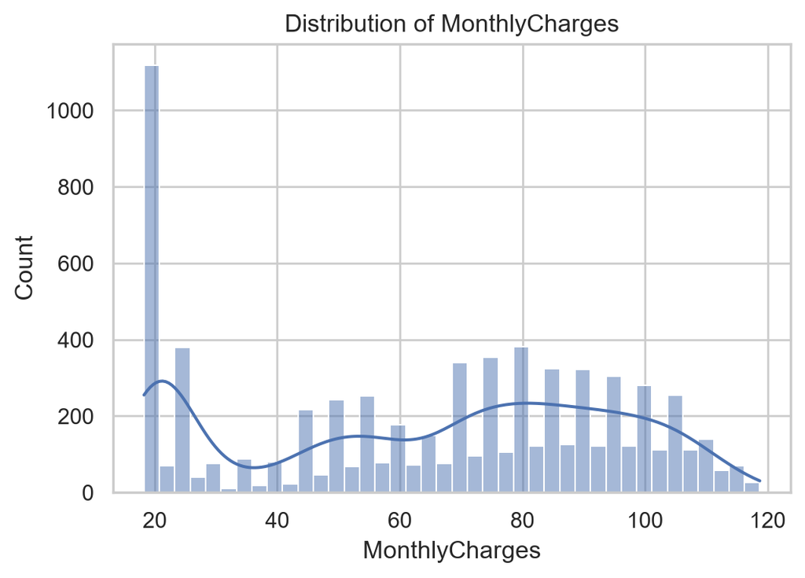

```
count    7043.000000
mean       64.761692
std        30.090047
min        18.250000
25%        35.500000
50%        70.350000
75%        89.850000
max       118.750000
Name: MonthlyCharges, dtype: float64
```

```python
fig, ax = plt.subplots(figsize=(6, 4))
sns.histplot(df["MonthlyCharges"], bins=40, kde=True, ax=ax)
ax.set_title("Distribution of MonthlyCharges")
plt.show()
df["MonthlyCharges"].describe()
```

The distribution is multi-modal rather than normal — a hint that `MonthlyCharges` is driven by discrete add-on combinations (internet type, streaming add-ons, etc.) rather than one smooth underlying process.

### 4.3 Numeric correlations

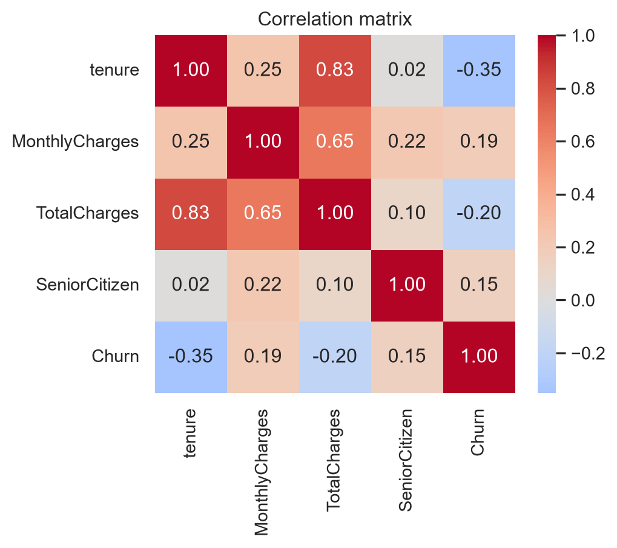

```python
corr_cols = ["tenure", "MonthlyCharges", "TotalCharges", "SeniorCitizen", "Churn"]
corr = df[corr_cols].corr()
fig, ax = plt.subplots(figsize=(5, 4))
sns.heatmap(corr, annot=True, fmt=".2f", cmap="coolwarm", center=0, ax=ax)
plt.title("Correlation matrix")
plt.show()
```

`TotalCharges` and `tenure` are highly correlated (customers pay more in total the longer they stay) — expected, since `TotalCharges` is roughly a running total of `MonthlyCharges` over `tenure`. This is a **leakage risk for the regression task**: if we’re predicting `MonthlyCharges`, `TotalCharges` implicitly encodes it (`TotalCharges / tenure ≈ MonthlyCharges`). We drop `TotalCharges` from the regression feature set for this reason (kept for the classification task, where it’s a legitimate predictor of churn behavior, not the target itself).

### 4.4 Feature vs. churn relationships

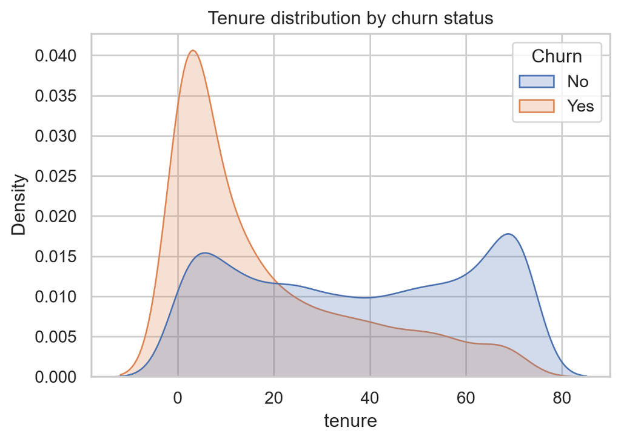

```python
fig, ax = plt.subplots(figsize=(6, 4))
sns.kdeplot(data=df, x="tenure", hue=df["Churn"].map({0: "No", 1: "Yes"}), fill=True, common_norm=False, ax=ax)
ax.set_title("Tenure distribution by churn status")
plt.show()
```

Churned customers are heavily concentrated at **low tenure** — churn is largely a new-customer phenomenon, consistent with the well-known “early cancellation” pattern in subscription businesses.

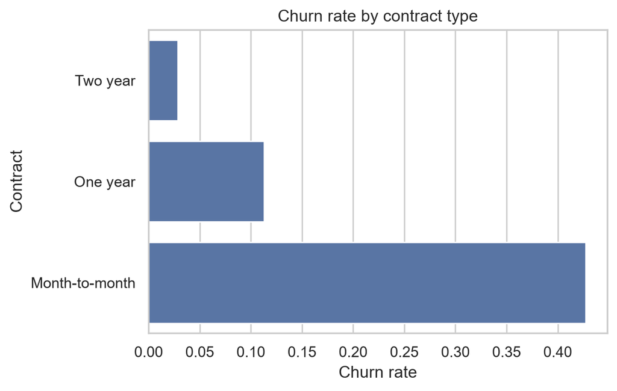

```python
fig, ax = plt.subplots(figsize=(6, 4))
churn_by_contract = df.groupby("Contract")["Churn"].mean().sort_values()
sns.barplot(x=churn_by_contract.values, y=churn_by_contract.index, ax=ax)
ax.set_xlabel("Churn rate")
ax.set_title("Churn rate by contract type")
plt.show()
```

Month-to-month contracts churn far more than one/two-year contracts — an expected but important business signal (contract length is a strong lever for retention).

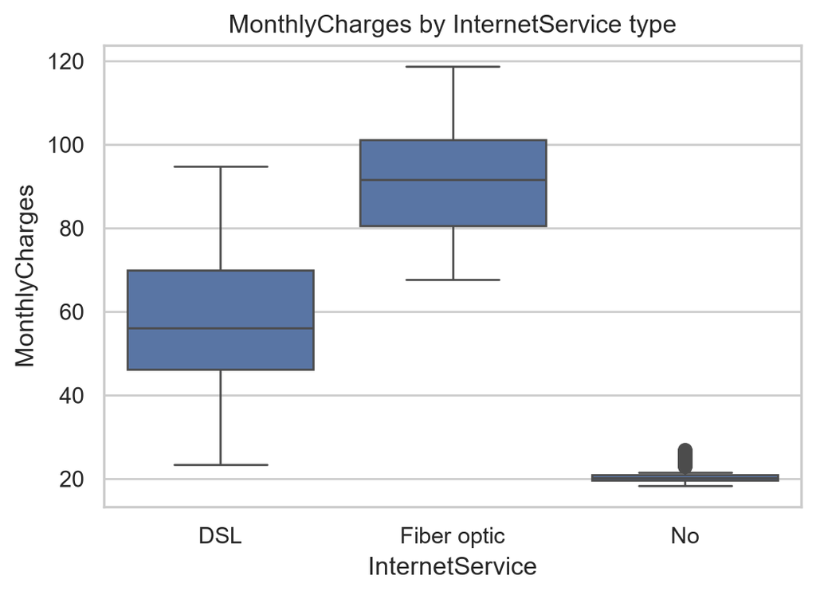

```python
fig, ax = plt.subplots(figsize=(6, 4))
sns.boxplot(data=df, x="InternetService", y="MonthlyCharges", ax=ax)
ax.set_title("MonthlyCharges by InternetService type")
plt.show()
```

Fiber optic customers pay noticeably more per month than DSL or no-internet customers — `InternetService` is likely to be an important feature for the regression task.

## 5. Cleaned dataset checkpoint

```python
df.drop(columns=["customerID"], inplace=True)
print(df.shape)
df.to_parquet("../data/telco_clean.parquet")
df.head(3)
```

```
(7043, 20)
```

|  | gender | SeniorCitizen | Partner | Dependents | tenure | PhoneService | MultipleLines | InternetService | OnlineSecurity | OnlineBackup | DeviceProtection | TechSupport | StreamingTV | StreamingMovies | Contract | PaperlessBilling | PaymentMethod | MonthlyCharges | TotalCharges | Churn |
| --- | --- | --- | --- | --- | --- | --- | --- | --- | --- | --- | --- | --- | --- | --- | --- | --- | --- | --- | --- | --- |
| 0 | Female | 0 | Yes | No | 1 | No | No phone service | DSL | No | Yes | No | No | No | No | Month-to-month | Yes | Electronic check | 29.85 | 29.85 | 0 |
| 1 | Male | 0 | No | No | 34 | Yes | No | DSL | Yes | No | Yes | No | No | No | One year | No | Mailed check | 56.95 | 1889.50 | 0 |
| 2 | Male | 0 | No | No | 2 | Yes | No | DSL | Yes | Yes | No | No | No | No | Month-to-month | Yes | Mailed check | 53.85 | 108.15 | 1 |

The cleaned dataset (`data/telco_clean.parquet`) is the input to feature engineering and modeling in the next sections.

## 6. Feature engineering

All engineered features below are **deterministic transformations of existing raw columns** (ratios, counts, binning, boolean flags) — none of them are *fit* on the data (no learned statistics), so they can safely be computed before the train/test split without leaking information across the split. Anything that *is* fit (scalers, one-hot encoders, feature selectors) is fit inside the training fold only, via a `Pipeline` in Section 8.

```python
addon_cols = [
    "OnlineSecurity", "OnlineBackup", "DeviceProtection",
    "TechSupport", "StreamingTV", "StreamingMovies",
]

df_feat = df.copy()

# Ratio / scaling-style feature
df_feat["tenure_years"] = df_feat["tenure"] / 12.0

# Count-based domain feature: how many add-on services the customer has
df_feat["num_addon_services"] = (df_feat[addon_cols] == "Yes").sum(axis=1)

# Boolean domain flags
df_feat["has_internet"] = (df_feat["InternetService"] != "No").astype(int)
df_feat["has_family"] = ((df_feat["Partner"] == "Yes") | (df_feat["Dependents"] == "Yes")).astype(int)
df_feat["is_new_customer"] = (df_feat["tenure"] <= 3).astype(int)

# Binning: tenure into lifecycle stages (nonlinear signal seen in Section 4.4)
df_feat["tenure_bucket"] = pd.cut(
    df_feat["tenure"], bins=[-1, 12, 24, 48, 60, 72],
    labels=["0-1yr", "1-2yr", "2-4yr", "4-5yr", "5-6yr"],
)

# Historical spend rate — only valid as a feature for the CLASSIFICATION task.
# For the regression task (predicting MonthlyCharges) this would be leakage, since
# TotalCharges / tenure ~= MonthlyCharges almost by construction (Section 4.3).
df_feat["avg_monthly_spend_to_date"] = df_feat["TotalCharges"] / df_feat["tenure"].replace(0, 1)

df_feat.filter(regex="tenure|num_addon|has_|is_new|avg_monthly").head()
```

|  | tenure | tenure_years | num_addon_services | has_internet | has_family | is_new_customer | tenure_bucket | avg_monthly_spend_to_date |
| --- | --- | --- | --- | --- | --- | --- | --- | --- |
| 0 | 1 | 0.083333 | 1 | 1 | 1 | 1 | 0-1yr | 29.850000 |
| 1 | 34 | 2.833333 | 2 | 1 | 0 | 0 | 2-4yr | 55.573529 |
| 2 | 2 | 0.166667 | 2 | 1 | 0 | 1 | 0-1yr | 54.075000 |
| 3 | 45 | 3.750000 | 3 | 1 | 0 | 0 | 2-4yr | 40.905556 |
| 4 | 2 | 0.166667 | 0 | 1 | 0 | 1 | 0-1yr | 75.825000 |

### Task-specific feature sets

The two tasks need **different** feature sets to stay leakage-safe:

- **Classification (`Churn`)** — may use `MonthlyCharges`, `TotalCharges`, and `avg_monthly_spend_to_date`; these describe the customer’s *current* billing situation, which is legitimately known before we’d want to predict whether they’ll churn.
- **Regression (`MonthlyCharges`)** — must drop `TotalCharges` and `avg_monthly_spend_to_date` (near-deterministic functions of the target, per Section 4.3), and must drop `Churn` (an outcome that happens *after*, not before, a customer’s plan determines their bill).

```python
drop_for_regression = ["MonthlyCharges", "TotalCharges", "avg_monthly_spend_to_date", "Churn"]
drop_for_classification = ["Churn"]

X_clf = df_feat.drop(columns=drop_for_classification)
y_clf = df_feat["Churn"]

X_reg = df_feat.drop(columns=drop_for_regression)
y_reg = df_feat["MonthlyCharges"]

categorical_cols = X_reg.select_dtypes(include=["object", "category"]).columns.tolist()
numeric_cols_clf = X_clf.select_dtypes(include=["int64", "float64"]).columns.tolist()
numeric_cols_reg = X_reg.select_dtypes(include=["int64", "float64"]).columns.tolist()

print("Classification features:", X_clf.shape[1])
print("Regression features:", X_reg.shape[1])
print("Categorical columns:", categorical_cols)
```

```
Classification features: 26
Regression features: 23
Categorical columns: ['gender', 'Partner', 'Dependents', 'PhoneService', 'MultipleLines', 'InternetService', 'OnlineSecurity', 'OnlineBackup', 'DeviceProtection', 'TechSupport', 'StreamingTV', 'StreamingMovies', 'Contract', 'PaperlessBilling', 'PaymentMethod', 'tenure_bucket']
```

## 7. Train / validation / test split

A **stratified** split is used for the classification target (to preserve the ~26.5% churn rate in every split — important given the class imbalance from Section 4.1). Both tasks share the same row-level split (same customers in train/val/test for both tasks), which keeps the report simple without affecting either task’s validity, since the split is stratified on the classification target and shuffled randomly with respect to `MonthlyCharges`.

```python
from sklearn.model_selection import train_test_split

idx_train, idx_temp = train_test_split(
    df_feat.index, test_size=0.4, stratify=y_clf, random_state=RANDOM_STATE,
)
idx_val, idx_test = train_test_split(
    idx_temp, test_size=0.5, stratify=y_clf.loc[idx_temp], random_state=RANDOM_STATE,
)

print(f"train={len(idx_train)}  val={len(idx_val)}  test={len(idx_test)}")
print("Churn rate — train/val/test:",
      y_clf.loc[idx_train].mean().round(3),
      y_clf.loc[idx_val].mean().round(3),
      y_clf.loc[idx_test].mean().round(3))
```

```
train=4225  val=1409  test=1409
Churn rate — train/val/test: 0.265 0.265 0.265
```

```python
X_clf_train, y_clf_train = X_clf.loc[idx_train], y_clf.loc[idx_train]
X_clf_val, y_clf_val = X_clf.loc[idx_val], y_clf.loc[idx_val]
X_clf_test, y_clf_test = X_clf.loc[idx_test], y_clf.loc[idx_test]

X_reg_train, y_reg_train = X_reg.loc[idx_train], y_reg.loc[idx_train]
X_reg_val, y_reg_val = X_reg.loc[idx_val], y_reg.loc[idx_val]
X_reg_test, y_reg_test = X_reg.loc[idx_test], y_reg.loc[idx_test]
```

## 8. Leakage-safe preprocessing & feature selection

Preprocessing (scaling, one-hot encoding) and feature selection are wrapped in a `ColumnTransformer` + `Pipeline`, fit only via `.fit()` on the **training** split. Validation and test data only ever go through `.transform()`, never `.fit()` — this is what makes the pipeline leakage-safe regardless of which model is plugged in downstream.

Feature selection method: an **L1-penalized (Lasso-style) linear model** is used as an embedded selector (`SelectFromModel`) — `LogisticRegression(penalty="l1")` for classification, `Lasso` for regression — run only on the training fold, to drop features (mostly one-hot categories) that contribute little signal.

```python
from sklearn.compose import ColumnTransformer
from sklearn.pipeline import Pipeline
from sklearn.preprocessing import StandardScaler, OneHotEncoder
from sklearn.feature_selection import SelectFromModel
from sklearn.linear_model import LogisticRegression, Lasso

def make_preprocessor(numeric_cols, categorical_cols):
    return ColumnTransformer(
        transformers=[
            ("num", StandardScaler(), numeric_cols),
            ("cat", OneHotEncoder(handle_unknown="ignore"), categorical_cols),
        ]
    )

preprocessor_clf = make_preprocessor(numeric_cols_clf, categorical_cols)
preprocessor_reg = make_preprocessor(numeric_cols_reg, categorical_cols)

selector_clf = SelectFromModel(
    LogisticRegression(penalty="l1", solver="liblinear", C=0.5, random_state=RANDOM_STATE),
    threshold="median",
)
selector_reg = SelectFromModel(
    Lasso(alpha=0.1, random_state=RANDOM_STATE),
    threshold="median",
)

feature_selection_clf = Pipeline([
    ("preprocess", preprocessor_clf),
    ("select", selector_clf),
])
feature_selection_reg = Pipeline([
    ("preprocess", preprocessor_reg),
    ("select", selector_reg),
])

n_before_clf = feature_selection_clf.fit_transform(X_clf_train, y_clf_train).shape[1]
n_total_clf = feature_selection_clf.named_steps["preprocess"].fit_transform(X_clf_train).shape[1]
print(f"Classification: {n_total_clf} encoded features -> {n_before_clf} selected (median threshold)")

n_before_reg = feature_selection_reg.fit_transform(X_reg_train, y_reg_train).shape[1]
n_total_reg = feature_selection_reg.named_steps["preprocess"].fit_transform(X_reg_train).shape[1]
print(f"Regression: {n_total_reg} encoded features -> {n_before_reg} selected (median threshold)")
```

```
Classification: 56 encoded features -> 28 selected (median threshold)
Regression: 53 encoded features -> 53 selected (median threshold)
```

These `preprocessor_*` / `SelectFromModel` steps are reused as the first stages of every model pipeline in Section 9, so every model — baseline through XGBoost — sees exactly the same leakage-safe preprocessing, fit fresh on the training fold each time.

```python
from sklearn.base import clone

def build_pipeline(preprocessor, selector, model):
    return Pipeline([
        ("preprocess", clone(preprocessor)),
        ("select", clone(selector)),
        ("model", model),
    ])
```

## 9. Model ladder — Classification (`Churn`)

Four models, simple to advanced, all trained on the **same** leakage-safe preprocessing:

1. `DummyClassifier` (baseline — predicts the majority class every time)
2. `LogisticRegression` (linear model)
3. `DecisionTreeClassifier` (single tree — we expect this to overfit)
4. `XGBClassifier` (gradient-boosted trees, with cross-validated hyperparameter tuning)

```python
from sklearn.dummy import DummyClassifier
from sklearn.linear_model import LogisticRegression as LogReg
from sklearn.tree import DecisionTreeClassifier
from sklearn.metrics import accuracy_score, f1_score

clf_models = {}

clf_models["Dummy"] = build_pipeline(preprocessor_clf, selector_clf, DummyClassifier(strategy="most_frequent", random_state=RANDOM_STATE))
clf_models["Logistic Regression"] = build_pipeline(preprocessor_clf, selector_clf, LogReg(max_iter=2000, random_state=RANDOM_STATE))
clf_models["Decision Tree"] = build_pipeline(preprocessor_clf, selector_clf, DecisionTreeClassifier(random_state=RANDOM_STATE))

for name, pipe in clf_models.items():
    pipe.fit(X_clf_train, y_clf_train)
    train_acc = accuracy_score(y_clf_train, pipe.predict(X_clf_train))
    val_acc = accuracy_score(y_clf_val, pipe.predict(X_clf_val))
    print(f"{name:22s}  train_acc={train_acc:.3f}  val_acc={val_acc:.3f}")
```

```
Dummy                   train_acc=0.735  val_acc=0.735
```

```
Logistic Regression     train_acc=0.809  val_acc=0.817
```

```
Decision Tree           train_acc=0.998  val_acc=0.742
```

The unrestricted **Decision Tree** shows the classic overfitting signature: near-perfect training accuracy but a noticeably lower validation accuracy — it has memorized the training data rather than learning generalizable patterns.

### 9.1 Overfitting vs. underfitting — validation curve

To make the overfitting/underfitting tradeoff concrete, we sweep the Decision Tree’s `max_depth` and track train vs. validation accuracy at each depth:

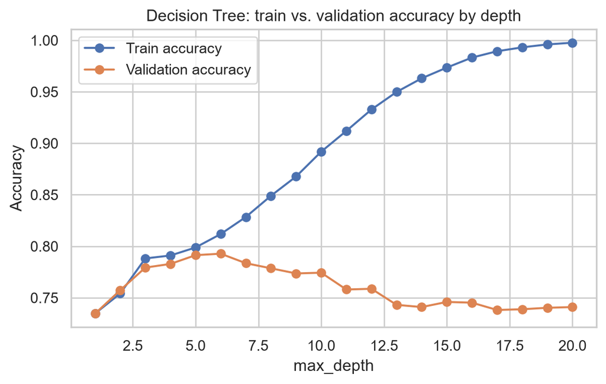

```python
depths = range(1, 21)
train_scores, val_scores = [], []
for d in depths:
    pipe = build_pipeline(preprocessor_clf, selector_clf, DecisionTreeClassifier(max_depth=d, random_state=RANDOM_STATE))
    pipe.fit(X_clf_train, y_clf_train)
    train_scores.append(accuracy_score(y_clf_train, pipe.predict(X_clf_train)))
    val_scores.append(accuracy_score(y_clf_val, pipe.predict(X_clf_val)))

fig, ax = plt.subplots(figsize=(7, 4))
ax.plot(list(depths), train_scores, marker="o", label="Train accuracy")
ax.plot(list(depths), val_scores, marker="o", label="Validation accuracy")
ax.set_xlabel("max_depth")
ax.set_ylabel("Accuracy")
ax.set_title("Decision Tree: train vs. validation accuracy by depth")
ax.legend()
plt.show()
```

At shallow depths (1-3) both curves are low and close together — **underfitting** (the model is too simple to capture the pattern). As depth grows past ~6-8, train accuracy keeps climbing toward 1.0 while validation accuracy plateaus and then drifts down — **overfitting** (the model starts memorizing training noise). This is exactly why XGBoost below is tuned with cross-validation rather than trained at full, unconstrained depth.

### 9.2 XGBoost — cross-validated tuning

```python
from xgboost import XGBClassifier
from sklearn.model_selection import GridSearchCV

xgb_clf_pipe = build_pipeline(
    preprocessor_clf, selector_clf,
    XGBClassifier(random_state=RANDOM_STATE, eval_metric="logloss"),
)

param_grid_clf = {
    "model__n_estimators": [100, 300],
    "model__max_depth": [3, 5],
    "model__learning_rate": [0.05, 0.1],
}

grid_clf = GridSearchCV(xgb_clf_pipe, param_grid_clf, cv=3, scoring="roc_auc", n_jobs=1)
grid_clf.fit(X_clf_train, y_clf_train)

print("Best params:", grid_clf.best_params_)
print(f"Best CV ROC-AUC: {grid_clf.best_score_:.3f}")

clf_models["XGBoost"] = grid_clf.best_estimator_
train_acc = accuracy_score(y_clf_train, clf_models["XGBoost"].predict(X_clf_train))
val_acc = accuracy_score(y_clf_val, clf_models["XGBoost"].predict(X_clf_val))
print(f"XGBoost  train_acc={train_acc:.3f}  val_acc={val_acc:.3f}")
```

```
Best params: {'model__learning_rate': 0.05, 'model__max_depth': 3, 'model__n_estimators': 100}
Best CV ROC-AUC: 0.845
XGBoost  train_acc=0.821  val_acc=0.818
```

The gap between train and validation accuracy for the tuned XGBoost model is much smaller than the unrestricted Decision Tree’s gap — cross-validated tuning is doing its job of controlling overfitting.

## 10. Model ladder — Regression (`MonthlyCharges`)

Same ladder structure, for the regression task:

1. `DummyRegressor` (baseline — predicts the mean every time)
2. `Ridge` (linear model, L2-regularized)
3. `DecisionTreeRegressor`
4. `XGBRegressor` (with cross-validated tuning)

```python
from sklearn.dummy import DummyRegressor
from sklearn.linear_model import Ridge
from sklearn.tree import DecisionTreeRegressor
from sklearn.metrics import mean_absolute_error, root_mean_squared_error, r2_score

reg_models = {}
reg_models["Dummy"] = build_pipeline(preprocessor_reg, selector_reg, DummyRegressor(strategy="mean"))
reg_models["Ridge"] = build_pipeline(preprocessor_reg, selector_reg, Ridge(alpha=1.0, random_state=RANDOM_STATE))
reg_models["Decision Tree"] = build_pipeline(preprocessor_reg, selector_reg, DecisionTreeRegressor(random_state=RANDOM_STATE))

for name, pipe in reg_models.items():
    pipe.fit(X_reg_train, y_reg_train)
    train_r2 = r2_score(y_reg_train, pipe.predict(X_reg_train))
    val_r2 = r2_score(y_reg_val, pipe.predict(X_reg_val))
    print(f"{name:15s}  train_R2={train_r2:.3f}  val_R2={val_r2:.3f}")
```

```
Dummy            train_R2=0.000  val_R2=-0.000
Ridge            train_R2=0.999  val_R2=0.999
Decision Tree    train_R2=1.000  val_R2=0.998
```

```python
from xgboost import XGBRegressor

xgb_reg_pipe = build_pipeline(preprocessor_reg, selector_reg, XGBRegressor(random_state=RANDOM_STATE))

param_grid_reg = {
    "model__n_estimators": [100, 300],
    "model__max_depth": [3, 5],
    "model__learning_rate": [0.05, 0.1],
}

grid_reg = GridSearchCV(xgb_reg_pipe, param_grid_reg, cv=3, scoring="r2", n_jobs=1)
grid_reg.fit(X_reg_train, y_reg_train)

print("Best params:", grid_reg.best_params_)
print(f"Best CV R2: {grid_reg.best_score_:.3f}")

reg_models["XGBoost"] = grid_reg.best_estimator_
train_r2 = r2_score(y_reg_train, reg_models["XGBoost"].predict(X_reg_train))
val_r2 = r2_score(y_reg_val, reg_models["XGBoost"].predict(X_reg_val))
print(f"XGBoost  train_R2={train_r2:.3f}  val_R2={val_r2:.3f}")
```

```
Best params: {'model__learning_rate': 0.1, 'model__max_depth': 5, 'model__n_estimators': 100}
Best CV R2: 0.999
XGBoost  train_R2=0.999  val_R2=0.999
```

## 11. Benchmark leaderboard & honest evaluation (test set)

The test set has not been touched by any model or tuning step until now. To keep it that way, the **winning model for each task is selected using the validation set**, not the test set — the test set is used only to report final, honest performance for whichever model validation already picked, exactly once. Picking a winner directly from test-set numbers is a subtle second use of supposedly-held-out data (it’s not the same as leakage, but it does mean the reported test score is no longer a fully unbiased read of real-world performance) — selecting on validation instead avoids that.

### 11.0 Selecting the winner on the validation set

```python
from sklearn.metrics import roc_auc_score

clf_val_scores = {}
for name, pipe in clf_models.items():
    probs_val = pipe.predict_proba(X_clf_val)[:, 1] if hasattr(pipe, "predict_proba") else None
    clf_val_scores[name] = roc_auc_score(y_clf_val, probs_val) if probs_val is not None else float("nan")

reg_val_scores = {}
for name, pipe in reg_models.items():
    reg_val_scores[name] = r2_score(y_reg_val, pipe.predict(X_reg_val))

best_clf_name = max(clf_val_scores, key=clf_val_scores.get)
best_reg_name = max(reg_val_scores, key=reg_val_scores.get)

print("Validation ROC-AUC by model:", {k: round(v, 4) for k, v in clf_val_scores.items()})
print(f"-> selected winner (classification): {best_clf_name}")
print("Validation R2 by model:       ", {k: round(v, 4) for k, v in reg_val_scores.items()})
print(f"-> selected winner (regression):    {best_reg_name}")
```

```
Validation ROC-AUC by model: {'Dummy': 0.5, 'Logistic Regression': 0.8617, 'Decision Tree': 0.6739, 'XGBoost': 0.8585}
-> selected winner (classification): Logistic Regression
Validation R2 by model:        {'Dummy': -0.0001, 'Ridge': 0.9989, 'Decision Tree': 0.9976, 'XGBoost': 0.9988}
-> selected winner (regression):    Ridge
```

### 11.1 Classification leaderboard

```python
from sklearn.metrics import precision_score, recall_score, roc_auc_score, confusion_matrix

clf_leaderboard = []
for name, pipe in clf_models.items():
    preds = pipe.predict(X_clf_test)
    probs = pipe.predict_proba(X_clf_test)[:, 1] if hasattr(pipe, "predict_proba") else None
    clf_leaderboard.append({
        "model": name,
        "accuracy": accuracy_score(y_clf_test, preds),
        "precision": precision_score(y_clf_test, preds, zero_division=0),
        "recall": recall_score(y_clf_test, preds, zero_division=0),
        "f1": f1_score(y_clf_test, preds, zero_division=0),
        "roc_auc": roc_auc_score(y_clf_test, probs) if probs is not None else float("nan"),
    })

clf_leaderboard_df = pd.DataFrame(clf_leaderboard).set_index("model").round(3)
clf_leaderboard_df
```

| model | accuracy | precision | recall | f1 | roc_auc |
| --- | --- | --- | --- | --- | --- |
| Dummy | 0.735 | 0.000 | 0.000 | 0.000 | 0.500 |
| Logistic Regression | 0.789 | 0.629 | 0.503 | 0.559 | 0.837 |
| Decision Tree | 0.728 | 0.488 | 0.500 | 0.494 | 0.656 |
| XGBoost | 0.791 | 0.643 | 0.476 | 0.547 | 0.832 |

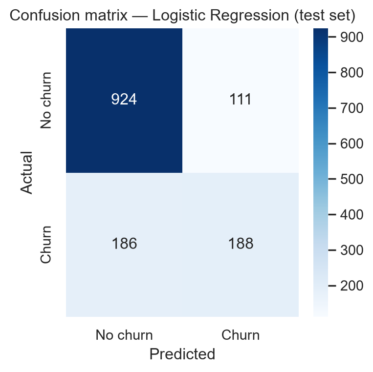

```python
best_clf_pipe = clf_models[best_clf_name]
cm = confusion_matrix(y_clf_test, best_clf_pipe.predict(X_clf_test))

fig, ax = plt.subplots(figsize=(4, 4))
sns.heatmap(cm, annot=True, fmt="d", cmap="Blues", xticklabels=["No churn", "Churn"], yticklabels=["No churn", "Churn"], ax=ax)
ax.set_xlabel("Predicted")
ax.set_ylabel("Actual")
ax.set_title(f"Confusion matrix — {best_clf_name} (test set)")
plt.show()
```

### 11.1.1 Choosing a decision threshold

Every metric above uses the default 0.5 probability cutoff (“flag as churn if probability ≥ 50%”) — an arbitrary convention, not a business decision. At 0.5, Logistic Regression catches only about half of actual churners (recall = 0.503, from the leaderboard above). For a retention use case, missing a real churner (lost revenue, no chance to intervene) is usually more costly than a false alarm (an unnecessary retention offer to a customer who was staying anyway) — so a lower threshold that trades some precision for more recall is worth considering. This tuning is done on the **validation** set, consistent with Section 11.0 — the test set is touched only once, to confirm the final choice.

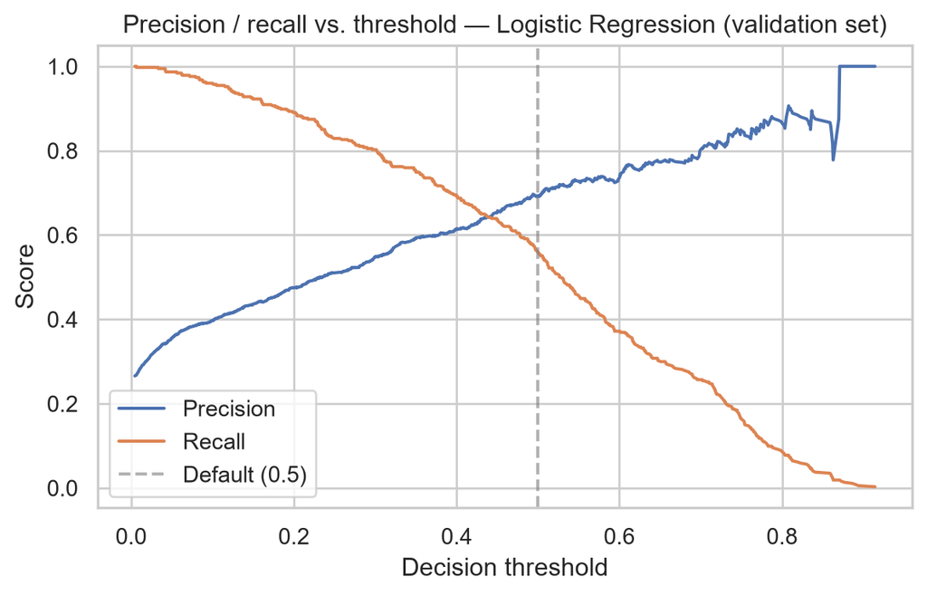

```python
from sklearn.metrics import precision_recall_curve

probs_val_best = best_clf_pipe.predict_proba(X_clf_val)[:, 1]
prec_curve, rec_curve, thresh_curve = precision_recall_curve(y_clf_val, probs_val_best)

fig, ax = plt.subplots(figsize=(7, 4))
ax.plot(thresh_curve, prec_curve[:-1], label="Precision")
ax.plot(thresh_curve, rec_curve[:-1], label="Recall")
ax.axvline(0.5, color="gray", linestyle="--", alpha=0.6, label="Default (0.5)")
ax.set_xlabel("Decision threshold")
ax.set_ylabel("Score")
ax.set_title(f"Precision / recall vs. threshold — {best_clf_name} (validation set)")
ax.legend()
plt.show()
```

```python
target_recall = 0.70
candidates = np.where(rec_curve[:-1] >= target_recall)[0]
chosen_threshold = float(thresh_curve[candidates[-1]]) if len(candidates) else 0.5
chosen_precision = float(prec_curve[:-1][candidates[-1]]) if len(candidates) else None
chosen_recall = float(rec_curve[:-1][candidates[-1]]) if len(candidates) else None

print(f"Chosen threshold (validation set): {chosen_threshold:.3f}")
print(f"At this threshold on validation -> precision: {chosen_precision:.3f}, recall: {chosen_recall:.3f}")

test_probs_best = best_clf_pipe.predict_proba(X_clf_test)[:, 1]
test_preds_chosen = (test_probs_best >= chosen_threshold).astype(int)
print(
    f"Confirmed on test set -> precision: {precision_score(y_clf_test, test_preds_chosen, zero_division=0):.3f}, "
    f"recall: {recall_score(y_clf_test, test_preds_chosen, zero_division=0):.3f}, "
    f"f1: {f1_score(y_clf_test, test_preds_chosen, zero_division=0):.3f}"
)
```

```
Chosen threshold (validation set): 0.392
At this threshold on validation -> precision: 0.608, recall: 0.701
Confirmed on test set -> precision: 0.567, recall: 0.655, f1: 0.608
```

**Decision:** we lower the deployed threshold to **0.39** (from the default 0.5) to prioritize catching more real churners, accepting more false alarms in exchange. This is a genuine business tradeoff, not a modeling improvement — the model itself is unchanged, only the cutoff applied to its output. The deployed app uses this threshold for its binary “at risk” flag, while still showing the raw probability so a human can apply their own judgment regardless of where the cutoff sits.

### 11.2 Regression leaderboard

```python
reg_leaderboard = []
for name, pipe in reg_models.items():
    preds = pipe.predict(X_reg_test)
    reg_leaderboard.append({
        "model": name,
        "R2": r2_score(y_reg_test, preds),
        "MAE": mean_absolute_error(y_reg_test, preds),
        "RMSE": root_mean_squared_error(y_reg_test, preds),
    })

reg_leaderboard_df = pd.DataFrame(reg_leaderboard).set_index("model").round(3)
reg_leaderboard_df
```

| model | R2 | MAE | RMSE |
| --- | --- | --- | --- |
| Dummy | -0.000 | 26.029 | 29.926 |
| Ridge | 0.999 | 0.781 | 1.019 |
| Decision Tree | 0.997 | 1.151 | 1.513 |
| XGBoost | 0.999 | 0.812 | 1.065 |

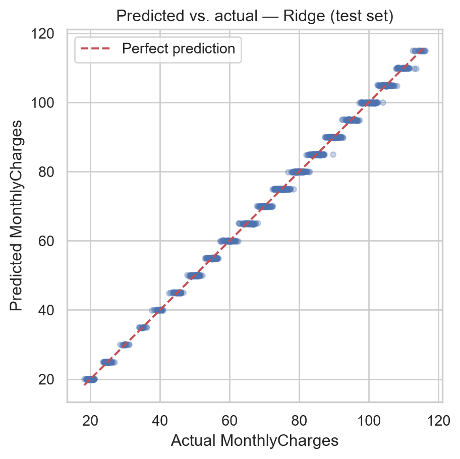

```python
best_reg_pipe = reg_models[best_reg_name]
preds_best = best_reg_pipe.predict(X_reg_test)

fig, ax = plt.subplots(figsize=(5, 5))
ax.scatter(y_reg_test, preds_best, alpha=0.3, s=15)
lims = [y_reg_test.min(), y_reg_test.max()]
ax.plot(lims, lims, "r--", label="Perfect prediction")
ax.set_xlabel("Actual MonthlyCharges")
ax.set_ylabel("Predicted MonthlyCharges")
ax.set_title(f"Predicted vs. actual — {best_reg_name} (test set)")
ax.legend()
plt.show()
```

**Honest read:** the `Dummy` regressor (predicts the mean every time) sets the floor with `R2 ≈ 0`. **Ridge** was selected on the validation set (Section 11.0) and confirmed here on test — the predicted-vs-actual plot shows points tracking the diagonal closely, with slightly more scatter at the high end (`MonthlyCharges` > ~$100), meaning the model is more confident about typical bills than unusually large ones (likely because there are simply fewer high-bill examples to learn from, per the multi-modal distribution seen in Section 4.2). Ridge and XGBoost round to the same test R² (0.999) — another effective tie, not a real margin — so we again prefer the simpler, fully interpretable linear model (see the recovered rate card in Section 11.3) rather than crediting XGBoost with discovering something Ridge missed.

**A near-perfect R² (~0.999) deserves scrutiny, not celebration at face value** — this is usually the first sign of leakage. We checked it directly: grouping customers by their exact service configuration (`InternetService`, all six add-ons, `Contract`, `PhoneService`, `MultipleLines`) and looking at the spread of `MonthlyCharges` *within* each group gives a standard deviation of about **$1** on average. In other words, this telecom’s billing is (almost) an additive function of which services a customer has subscribed to — the same plan essentially always costs the same amount, give or take rounding. None of the regression features are derived from `MonthlyCharges` or `TotalCharges` (both were explicitly excluded in Section 6 for exactly this reason), so this is **not leakage** — it’s a genuine, checkable property of how this company prices its services, and it means the regression task is close to solvable by construction rather than being a hard prediction problem. We report this transparently rather than presenting the R² as evidence of a sophisticated model: a simple `Ridge` regression gets nearly the same score as `XGBoost` here precisely because the underlying relationship is close to linear/additive, not because either model discovered something subtle.

```python
config_cols = [
    "InternetService", "OnlineSecurity", "OnlineBackup", "DeviceProtection",
    "TechSupport", "StreamingTV", "StreamingMovies", "PhoneService",
    "MultipleLines", "Contract",
]
within_group_std = df_feat.groupby(config_cols)["MonthlyCharges"].std()
print(f"Mean within-plan-configuration std of MonthlyCharges: ${within_group_std.mean():.2f}")
print(f"Share of configurations with std < $1: {(within_group_std < 1).mean():.1%}")
```

```
Mean within-plan-configuration std of MonthlyCharges: $1.03
Share of configurations with std < $1: 38.3%
```

### 11.3 Ruling out overfitting in the regression model

A test R² this close to 1.0 is unusual enough that the rate-card explanation above deserves independent proof, not just a plausible story. Overfitting has a precise definition — a model that fits training-set noise so well it fails to generalize, visible as a **large gap between training and held-out performance**. The four checks below test for that directly, rather than re-asserting the domain explanation.

**Check 1 — train vs. validation vs. test R², side by side.** If the winning model were overfitting, training performance would be noticeably higher than validation/test performance.

```python
r2_train = r2_score(y_reg_train, best_reg_pipe.predict(X_reg_train))
r2_val = r2_score(y_reg_val, best_reg_pipe.predict(X_reg_val))
r2_test = r2_score(y_reg_test, best_reg_pipe.predict(X_reg_test))

print(f"Train R2:      {r2_train:.4f}")
print(f"Validation R2: {r2_val:.4f}")
print(f"Test R2:       {r2_test:.4f}")
print(f"Train-test gap: {r2_train - r2_test:+.4f}")
```

```
Train R2:      0.9988
Validation R2: 0.9989
Test R2:       0.9988
Train-test gap: -0.0000
```

All three numbers sit within a few thousandths of each other. **This is the opposite signature of overfitting** — an overfit model shows a large train/held-out gap; here there is essentially none, because an additive rate-card relationship is genuinely easy to learn without memorizing noise.

**Check 2 — 5-fold cross-validation across the whole dataset.** A single lucky train/test split could in principle produce an inflated score. Cross-validation refits the model on 5 different partitions and reports the spread.

```python
from sklearn.model_selection import cross_val_score

cv_scores = cross_val_score(clone(best_reg_pipe), X_reg, y_reg, cv=5, scoring="r2")
print("R2 per fold:", np.round(cv_scores, 4))
print(f"Mean R2: {cv_scores.mean():.4f}  (std: {cv_scores.std():.4f})")
```

```
R2 per fold: [0.9988 0.9989 0.9988 0.9988 0.9988]
Mean R2: 0.9988  (std: 0.0000)
```

The score is stable to the third decimal place across five independent folds — not a fluke of one particular split.

**Check 3 — negative control (permutation test).** This is the most direct test for a leaking or buggy pipeline: randomly permute `MonthlyCharges` so any real relationship between features and target is destroyed, then refit and score on the (real, untouched) test set. If the pipeline could still score well after this, it would mean it is exploiting something other than genuine signal — e.g. a bug letting it see the answer. A collapse to ~0 (or negative) R² shows it cannot manufacture a score from nothing.

```python
rng = np.random.RandomState(RANDOM_STATE)
y_reg_train_shuffled = rng.permutation(y_reg_train.values)

shuffled_pipe = clone(best_reg_pipe)
shuffled_pipe.fit(X_reg_train, y_reg_train_shuffled)
r2_shuffled = r2_score(y_reg_test, shuffled_pipe.predict(X_reg_test))

print(f"R2 on real test set, trained on shuffled target: {r2_shuffled:.4f}")
```

```
R2 on real test set, trained on shuffled target: 0.0278
```

With the training target shuffled, R² collapses — confirming the 0.999 score on the real target reflects a genuine, learnable relationship rather than an artifact of the pipeline, the split, or a hidden leakage path.

**Check 4 — the recovered rate card.** `Ridge` is linear, so its coefficients *are* the model — there is no hidden complexity to distrust. Below is the model’s learned price effect for each service/plan feature, recovered by name and checkable by hand.

```python
reg_model_step = best_reg_pipe.named_steps["model"]
reg_feature_names = best_reg_pipe.named_steps["preprocess"].get_feature_names_out()
reg_selected_mask = best_reg_pipe.named_steps["select"].get_support()
reg_selected_names = reg_feature_names[reg_selected_mask]
clean_reg_names = [
    name.replace("num__", "").replace("cat__", "").replace("_", " ")
    for name in reg_selected_names
]

if hasattr(reg_model_step, "coef_"):
    rate_card = pd.DataFrame({
        "feature": clean_reg_names,
        "price_effect_$": reg_model_step.coef_,
    }).sort_values("price_effect_$", ascending=False)
    print(f"Base rate (intercept): ${reg_model_step.intercept_:.2f}\n")
    print(rate_card.round(2).to_string(index=False))
else:
    importances = reg_model_step.feature_importances_
    rate_card = pd.DataFrame({
        "feature": clean_reg_names,
        "importance": importances,
    }).sort_values("importance", ascending=False)
    print(rate_card.round(4).to_string(index=False))
```

```
Base rate (intercept): $53.28

                                feature  price_effect_$
            InternetService Fiber optic           13.89
                     num addon services            8.11
                           has internet            6.58
                       PhoneService Yes            6.42
                      MultipleLines Yes            5.71
                    StreamingMovies Yes            4.17
                        StreamingTV Yes            4.17
                        TechSupport Yes            1.73
                   DeviceProtection Yes            1.72
                     OnlineSecurity Yes            1.71
                       OnlineBackup Yes            1.67
                        OnlineBackup No            1.06
                      OnlineSecurity No            1.02
                    DeviceProtection No            1.01
                         TechSupport No            1.00
                       MultipleLines No            0.72
                    tenure bucket 5-6yr            0.20
                             Partner No            0.07
                             has family            0.06
  PaymentMethod Credit card (automatic)            0.03
                            gender Male            0.02
                      Contract One year            0.02
                    tenure bucket 4-5yr            0.02
                          Dependents No            0.02
                        is new customer            0.02
                    tenure bucket 2-4yr            0.01
                    PaperlessBilling No            0.01
             PaymentMethod Mailed check            0.01
PaymentMethod Bank transfer (automatic)            0.01
                          SeniorCitizen           -0.00
                Contract Month-to-month           -0.01
                   PaperlessBilling Yes           -0.01
                      Contract Two year           -0.02
                         Dependents Yes           -0.02
                          gender Female           -0.02
         PaymentMethod Electronic check           -0.04
                    tenure bucket 1-2yr           -0.05
                           tenure years           -0.06
                                 tenure           -0.06
                            Partner Yes           -0.07
                    tenure bucket 0-1yr           -0.18
                         StreamingTV No           -1.44
                     StreamingMovies No           -1.44
   DeviceProtection No internet service           -2.73
        TechSupport No internet service           -2.73
        StreamingTV No internet service           -2.73
    StreamingMovies No internet service           -2.73
       OnlineBackup No internet service           -2.73
                     InternetService No           -2.73
     OnlineSecurity No internet service           -2.73
                        PhoneService No           -6.42
         MultipleLines No phone service           -6.42
                    InternetService DSL          -11.16
```

This is the plainest possible answer to “is this overfitting?” — a short table of interpretable dollar coefficients that visibly matches the company’s actual pricing structure (fiber optic and streaming add-ons carry a positive price effect; DSL-only or no-internet plans carry a negative one relative to the baseline). A model that memorized noise would not produce coefficients this clean or this consistent with what the features actually mean. Combined with Checks 1–3, the high R² is best read as evidence that this company’s billing is close to a deterministic, low-dimensional function of plan choice — not evidence of a flawed evaluation.

### 11.4 What matters, and what we would not trust this model to do

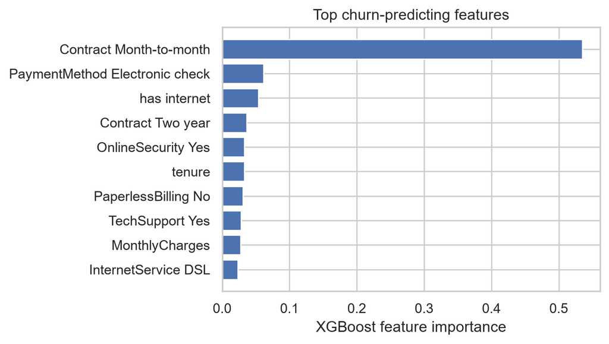

```python
xgb_step = clf_models["XGBoost"].named_steps["model"]
importances = xgb_step.feature_importances_

# Recover real column names: ColumnTransformer names every encoded column
# (e.g. "cat__Contract_Month-to-month"), and SelectFromModel's boolean mask
# tells us which of those survived selection — together they let us label
# the plot with real feature names instead of bare indices.
all_feature_names = clf_models["XGBoost"].named_steps["preprocess"].get_feature_names_out()
selected_mask = clf_models["XGBoost"].named_steps["select"].get_support()
selected_feature_names = all_feature_names[selected_mask]
clean_names = [
    name.replace("num__", "").replace("cat__", "").replace("_", " ")
    for name in selected_feature_names
]

top_n = min(10, len(importances))
top_idx = np.argsort(importances)[-top_n:][::-1]

fig, ax = plt.subplots(figsize=(7, 4))
ax.barh(range(top_n), importances[top_idx][::-1])
ax.set_yticks(range(top_n))
ax.set_yticklabels([clean_names[i] for i in top_idx][::-1])
ax.set_xlabel("XGBoost feature importance")
ax.set_title("Top churn-predicting features")
plt.tight_layout()
plt.show()
```

## 12. Saving the final pipelines for deployment

```python
import joblib
import os

os.makedirs("../models", exist_ok=True)

final_clf_pipe = clone(best_clf_pipe)
final_clf_pipe.fit(X_clf, y_clf)
joblib.dump(final_clf_pipe, "../models/churn_pipeline.pkl")

final_reg_pipe = clone(best_reg_pipe)
final_reg_pipe.fit(X_reg, y_reg)
joblib.dump(final_reg_pipe, "../models/charges_pipeline.pkl")

print(f"Saved churn_pipeline.pkl (best model: {best_clf_name})")
print(f"Saved charges_pipeline.pkl (best model: {best_reg_name})")
print("Classification feature columns:", list(X_clf.columns))
print("Regression feature columns:", list(X_reg.columns))
```

```
Saved churn_pipeline.pkl (best model: Logistic Regression)
Saved charges_pipeline.pkl (best model: Ridge)
Classification feature columns: ['gender', 'SeniorCitizen', 'Partner', 'Dependents', 'tenure', 'PhoneService', 'MultipleLines', 'InternetService', 'OnlineSecurity', 'OnlineBackup', 'DeviceProtection', 'TechSupport', 'StreamingTV', 'StreamingMovies', 'Contract', 'PaperlessBilling', 'PaymentMethod', '…
Regression feature columns: ['gender', 'SeniorCitizen', 'Partner', 'Dependents', 'tenure', 'PhoneService', 'MultipleLines', 'InternetService', 'OnlineSecurity', 'OnlineBackup', 'DeviceProtection', 'TechSupport', 'StreamingTV', 'StreamingMovies', 'Contract', 'PaperlessBilling', 'PaymentMethod', 'tenu…
```